# Chap3. Graphics with ggplot2

LEE EUN JU

### tidyverse

ggplot2, dplyr, tidyr, readr, purrr, tibble, stringr, forcats  
* ggplot2 : graph 제작  
* dplyr : data 조작에 대한 문법  
* tidyr : tidy data 사용  
* readr : rectangular data를 읽어 오는 방법 * purr : 함수와 벡터를 이용한 프로그래밍을 하여 반복루프 시간 단축  
* tibble : 데이터프레임의 한 형태  
* stringr : 가능한 쉽게 문자열을 사용하도록 돕는 tool * forcats : factor에 대한 문제를 해결하기 위한 tool

- pipes %>% : 생각하는 순서대로 코드를 짤 수 있다.

```r
sqrt(83)
```

```
## [1] 9.110434
```

```r
round(sqrt(83), digits=2)
```

```
## [1] 9.11
```

```r
sqrt(83) %>% round(digits=2)
```

```
## [1] 9.11
```

pipes - My turn

```r
data(diamonds)
diamonds %>% head(10)
diamonds %>% head() %>% summary()
```

[output not shown]

### ggplot

[ggplot2]  
* ggplot2안에서 통계량을 구하여 그래프 그릴 수 있움  
* mappings(aes) : 어느 변수가 올것이냐 -> 무조건 변수(열들)만 들어옴  
* layers : 그래프 추가=> + 이용  
* coord : x축/y축 뒤집기 등  
* facetting : 각각 그리고자 하는 경우 * facet_wrap: 하나의 변수만 가능, facet_grid: 두개의 변수 가능  
* theme : 테마

[mpg data]  
- 데이터 안에 데이터 변수의 의미를 파악하는 것이 중요  
: 엔진사이즈 크기에 따른 엔진의 효율성?

```
## # A tibble: 234 x 11
##    manufacturer model    displ  year   cyl trans   drv     cty   hwy fl    class
##    <chr>        <chr>    <dbl> <int> <int> <chr>   <chr> <int> <int> <chr> <chr>
##  1 audi         a4         1.8  1999     4 auto(l~ f        18    29 p     comp~
##  2 audi         a4         1.8  1999     4 manual~ f        21    29 p     comp~
##  3 audi         a4         2    2008     4 manual~ f        20    31 p     comp~
##  4 audi         a4         2    2008     4 auto(a~ f        21    30 p     comp~
##  5 audi         a4         2.8  1999     6 auto(l~ f        16    26 p     comp~
##  6 audi         a4         2.8  1999     6 manual~ f        18    26 p     comp~
##  7 audi         a4         3.1  2008     6 auto(a~ f        18    27 p     comp~
##  8 audi         a4 quat~   1.8  1999     4 manual~ 4        18    26 p     comp~
##  9 audi         a4 quat~   1.8  1999     4 auto(l~ 4        16    25 p     comp~
## 10 audi         a4 quat~   2    2008     4 manual~ 4        20    28 p     comp~
## # ... with 224 more rows
```

Common problems - ggplot사용 시, +을 아래에 두면 실행되지 않는다.

```r
ggplot(data=mpg)
+ geom_point(mapping=aes(x=displ, y=hwy, shape=class))
```

### 1. Scatter plot - geom_point()

```r
ggplot(data=mpg)+ geom_point(mapping=aes(x=displ, y=hwy))
```

[output not shown]

```r
# %>% 사용
mpg %>%
  ggplot()+
  geom_point(mapping=aes(x=displ, y=hwy))
```

[output not shown]

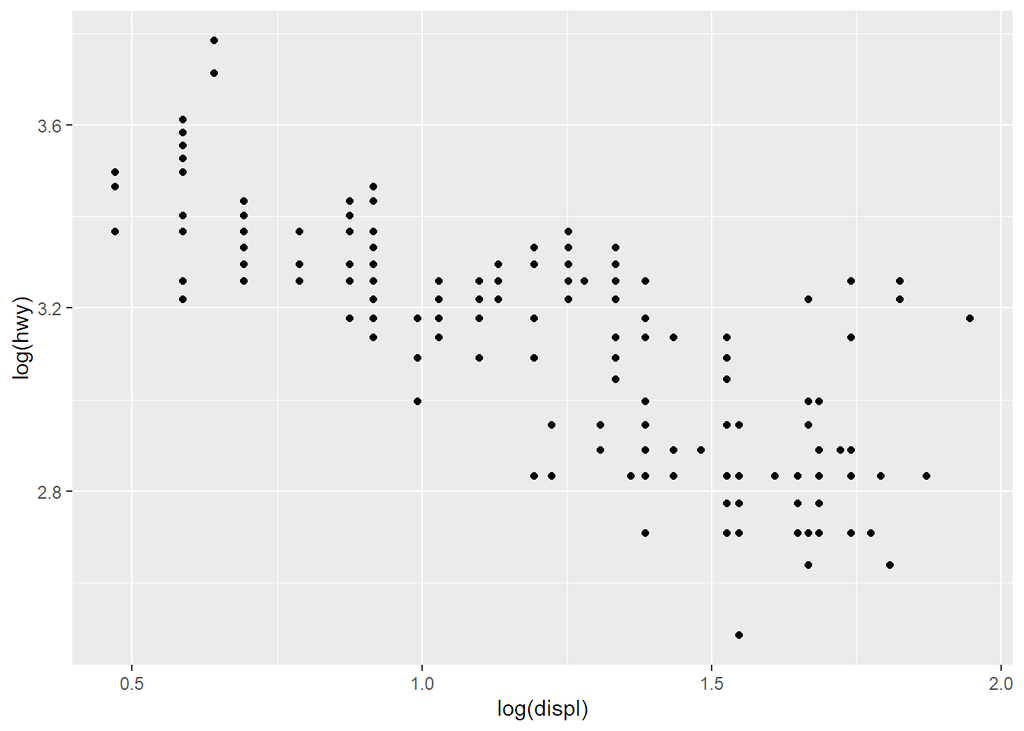

```r
#log화
mpg %>%
  ggplot()+
  geom_point(mapping=aes(x=log(displ), y=log(hwy)))
```